# Data 605 - Assignment 13

Leticia Salazar

4/23/2022

### Univariate & Multivariate Calculus

#### **1. Use integration by substitution to solve the integral below.**

$\int4e^{-7x}dx$

#### Solution:

##### Key:

u = -7x

du = -7dx

$\int4e^{-7x}dx = \int \frac{-7x4}{-7} e^{-7x} dx$

$=\int\frac{-4}{7} e^{u} du$

$=\frac{-4}{7}e^u + C$

$=-\frac{4}{7}e^{-7x} + C$

$~$

#### **2. Biologists are treating a pond contaminated with bacteria. The level of contamination is changing at a rate of $\frac{dN}{dt} = \frac{3150}{t^4}$ bacteria per cubic centimeter per day, where *t* is the number of days since treatment began. Find a function N(t) to estimate the level of contamination if the level after 1 day was 6530 bacteria per cubic centimeter.**

###### Disclaimer: I am not 100% on the approach or solution but attempted to understand it and solve it.

##### Given:

$\frac{dN}{dt} = N'(t)$

#### Solution:

$=-\frac{3150}{t^4}-220$

$N(t) = \int(\frac{-3150}{t^4} -220)dt=\frac{1050}{t^3}-200t + C$

$N(1) = 6530$

$N(t) = \frac{1050}{t^3} -220t +C$

$= \frac{1050}{1^3}-220 * 1 + C = 6530$

$C = 6530 - 1050 +220$

C = 5700

$~$

#### **3. Find the total area of the red rectangles in the figure below, where the equation of the line is f(x) = 2x - 9**

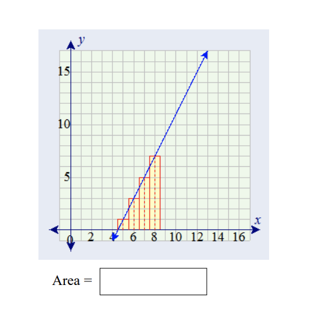

#### Solution:

f(x) = 2x - 9

$\int_{4.5}^{8.5} 2x = 9dx$

$=[x^2 - 9x]|^{8.5}_{4.5}$

$=(8.5^2 - 9(8.5))-(4.5^2 - 9(4.5))$

Area of red rectangles = 16

$~$

#### **4. Find the area of the region bounded by the graphs of the given equations.**

$y = x^2 - 2x - 2$, $y = x + 2$

#### Enter your answer below

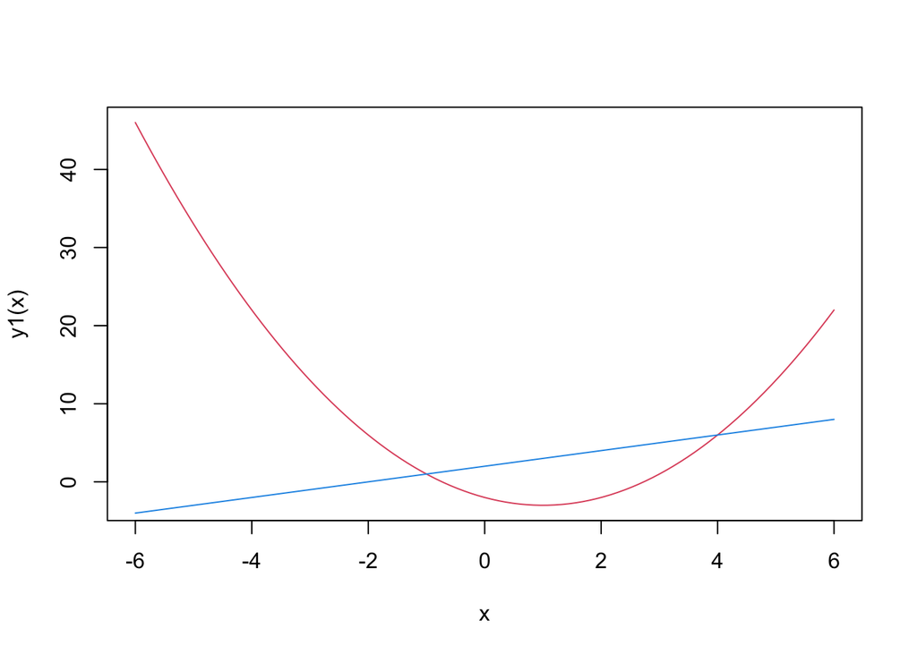

```r
# Create funtions
y1 <- function(x){x^2 - (2*x) - 2}
y2 <- function(x){x + 2}

# plot lines
curve(y1, from = -6, to = 6, col = 2)
curve(y2, from = -6, to = 6, add = TRUE, col = 4)
```

```r
integrate(y1, lower = -1, upper = 4)
```

```
## -3.333333 with absolute error < 1.2e-13
```

```r
integrate(y2, lower = -1, upper = 4)
```

```
## 17.5 with absolute error < 1.9e-13
```

```r
total_area = 17.5 - (-3.33)
total_area
```

```
## [1] 20.83
```

$~$

#### **5. A beauty supply store expects to sell 110 flat irons during the next year. It costs $3.75 to store one flat iron for one year. There is a fixed cost of $8.25 for each order. Find the lot size and the number of orders per year that will minimize inventory costs.**

#### Solution:

n = number orders per year

x = number of flat irons to order per year

x / 2 = average inventory level

Storage cost = 3.75 * (x / 2) Storage cost = 1.875x

Order cost = 8.25 * 110 / x Order cost = 907.5 / x

Inventory cost = 1.875x + (907.5 /x)

Therefore:

1.875 - 907.5 * x - 2 = 0

x = $\sqrt484$

**x = 22**

Orders per year = 110 / n = 22

**n = 5**

$~$

#### **6. Use integration by parts to solve the integral below**

$\int ln(9x) * x^6 dx$

#### Solution:

u = In(9x) therefore du = $\frac{1}{x}dx$

v = $\frac{1}{7}x^7$ therefore $dv = x^6dx$

With integration we get $\int uv' = uv = \int u'v$

$\int ln(9x)x^6dx = ln(9x)\frac{1}{7}x^7 - \int\frac{1}{x}\frac{1}{7}x^7dx$

$= \frac{1}{7}ln(9x)x^7 - \frac{1}{49}x^7 +C$

$(\frac{1}{7}ln(9x)x^7 - \frac{1}{49}x^7 +C$

$~$

#### **7. Determine whether f ( x ) is a probability density function on the interval $[1, e^6]$. If not, determine the value of the definite integral.**

$f(x) = \frac{1}{6x}$

#### Solution:

$\int_{1}^{e^6} \frac{1}{6x}dx = \frac{1}{6}int_{1}^{e^6}\frac{1}{x}dx$

$= \frac{1}{6}(ln(e^6) - ln(1))$

= 1 therefore f(x) is a probability density function on the interval $[1, e^6]$